# HW4

Hakan Ekiz - IE360 - Fall2020

28 Ocak 2021

## Introduction

In this study, we will work on the dataset obtained from EPİAŞ. Electricity consumption is not static like many things. However, in order to produce linear models, we will try to stabilize the data as much as we can and estimate daily consumption. Stationary data should have mean and variance that do not change over time.

These kinds of problems are important for planning. For processes such as determining and transporting the amount of electricity to be produced and purchased, it is critical to make estimation models by stabilizing the non-stationary data.

## Data

```
##         Tarih  Saat Tüketim.Miktarı..MWh.
## 1  01.01.2017 00:00             27.223,06
## 2  01.01.2017 01:00             25.825,90
## 3  01.01.2017 02:00             24.252,68
## 4  01.01.2017 03:00             22.915,47
## 5  01.01.2017 04:00             22.356,99
## 6  01.01.2017 05:00             22.274,49
## 7  01.01.2017 06:00             22.388,61
## 8  01.01.2017 07:00             22.608,23
## 9  01.01.2017 08:00             22.547,94
## 10 01.01.2017 09:00             23.844,14
```

Data is taken from EPİAŞ platform. Before working on the data, some operations have been applied to bring it into the format we want. Afterwards, the hourly data set was converted into a daily data set:

```
##           Date mean_consumption
##  1: 2017-01-01         27099.66
##  2: 2017-01-02         33141.88
##  3: 2017-01-03         34769.59
##  4: 2017-01-04         35250.70
##  5: 2017-01-05         35109.35
##  6: 2017-01-06         33866.49
##  7: 2017-01-07         32339.15
##  8: 2017-01-08         30098.06
##  9: 2017-01-09         34605.60
## 10: 2017-01-10         35508.33
```

Before starting everything, it is useful to look at the change of data depending on time:

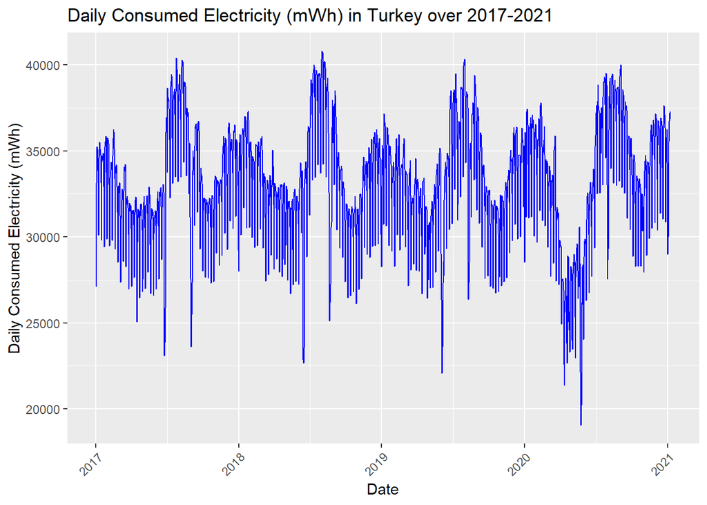

As can be seen from the graph, electricity usage fluctuates depending on time. Similar oscillations over similar periods show us seasonality.

It can be useful to use lags over certain time periods to stabilize data. So we can look at autocorrelation graphs.:

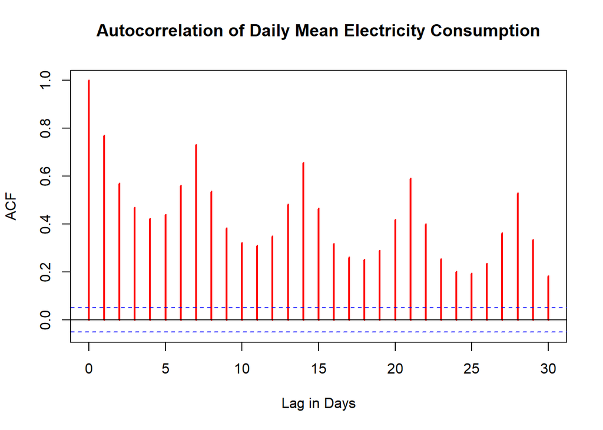

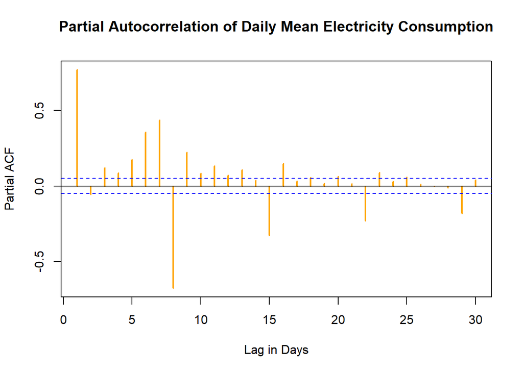

By looking at these graphs, we can observe that the autocorrelation values are high in the 1st and 7th lags. This shows us that we can use the consumption values of the days before and the previous week to estimate the values of the new day. That’s why we write the values one week ago and one day ago in the columns.

Then, we observe the effects with a simple model and establish the basic model. (non-stationary)

```
##
## Call:
## lm(formula = mean_consumption ~ prevday + prevweek, data = daily_elec)
##
## Residuals:
##     Min      1Q  Median      3Q     Max
## -8478.3  -976.1   -43.5   924.7  9088.7
##
## Coefficients:
##              Estimate Std. Error t value Pr(>|t|)
## (Intercept) 1.518e+03  5.174e+02   2.933   0.0034 **
## prevday     5.327e-01  1.660e-02  32.088   <2e-16 ***
## prevweek    4.223e-01  1.645e-02  25.673   <2e-16 ***
## ---
## Signif. codes:  0 '***' 0.001 '**' 0.01 '*' 0.05 '.' 0.1 ' ' 1
##
## Residual standard error: 1837 on 1466 degrees of freedom
## Multiple R-squared:  0.721,  Adjusted R-squared:  0.7207
## F-statistic:  1895 on 2 and 1466 DF,  p-value: < 2.2e-16
```

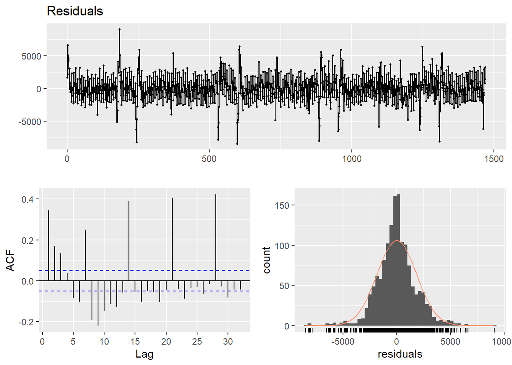

```
##
##  Breusch-Godfrey test for serial correlation of order up to 10
##
## data:  Residuals
## LM test = 642.13, df = 10, p-value < 2.2e-16
```

Unit Root KPSS test can be executed on the series to check if the assumption of stationarity is violated, in other words can be rejected,

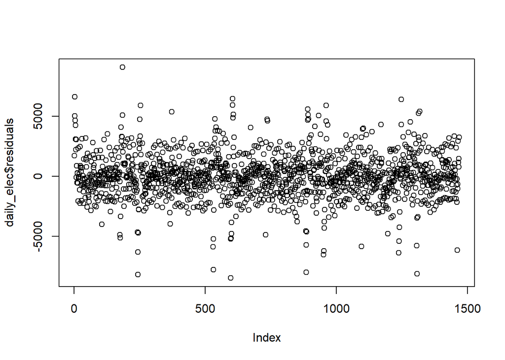

```
##
## #######################
## # KPSS Unit Root Test #
## #######################
##
## Test is of type: mu with 7 lags.
##
## Value of test-statistic is: 0.0321
##
## Critical value for a significance level of:
##                 10pct  5pct 2.5pct  1pct
## critical values 0.347 0.463  0.574 0.739
```

Although a certain line can be seen on the graph, outliers are observed, it is useful to look at the extreme values to reduce them.

## Outliers

To look for outliers in Turkey will be useful to look at the holidays. When we look at these days, deviations from the expected values are more than other days.

```
##           Date mean_consumption  prevday prevweek  residuals special      new
##  1: 2017-01-01         27099.66 25000.00 25000.00 1707.07457       1 25392.59
##  2: 2017-01-02         33141.88 27099.66 25000.00 6630.81603       0 33141.88
##  3: 2017-01-03         34769.59 33141.88 25000.00 5039.87047       0 34769.59
##  4: 2017-01-04         35250.70 34769.59 25000.00 4653.90195       0 35250.70
##  5: 2017-01-05         35109.35 35250.70 25000.00 4256.27231       0 35109.35
##  6: 2017-01-06         33866.49 35109.35 25000.00 3088.70091       0 33866.49
##  7: 2017-01-07         32339.15 33866.49 25000.00 2223.43133       0 32339.15
##  8: 2017-01-08         30098.06 32339.15 27099.66  -90.74696       0 30098.06
##  9: 2017-01-09         34605.60 30098.06 33141.88 3058.94896       0 34605.60
## 10: 2017-01-10         35508.33 34605.60 34769.59  873.15235       0 35508.33
##     initialpred prevday2 prevweek2
##  1:    25392.59 25000.00  25000.00
##  2:    26511.07 25392.59  25000.00
##  3:    29729.72 33141.88  25000.00
##  4:    30596.80 34769.59  25000.00
##  5:    30853.08 35250.70  25000.00
##  6:    30777.79 35109.35  25000.00
##  7:    30115.72 33866.49  25000.00
##  8:    30188.81 32339.15  25392.59
##  9:    31546.65 30098.06  33141.88
## 10:    34635.18 34605.60  34769.59
```

In order to correct these values, we defined a binary variable for special days and wrote the prediction we obtained from the first draft model we built these days.

Since changing values will affect our model, we will reconstruct the model.

```
##
## Call:
## lm(formula = new ~ prevday2 + prevweek2, data = daily_elec)
##
## Residuals:
##     Min      1Q  Median      3Q     Max
## -9781.8  -891.8   -51.1   834.2  8571.1
##
## Coefficients:
##              Estimate Std. Error t value Pr(>|t|)
## (Intercept) 1.255e+03  4.553e+02   2.757   0.0059 **
## prevday2    4.014e-01  1.600e-02  25.090   <2e-16 ***
## prevweek2   5.618e-01  1.583e-02  35.484   <2e-16 ***
## ---
## Signif. codes:  0 '***' 0.001 '**' 0.01 '*' 0.05 '.' 0.1 ' ' 1
##
## Residual standard error: 1589 on 1466 degrees of freedom
## Multiple R-squared:  0.7747, Adjusted R-squared:  0.7744
## F-statistic:  2521 on 2 and 1466 DF,  p-value: < 2.2e-16
```

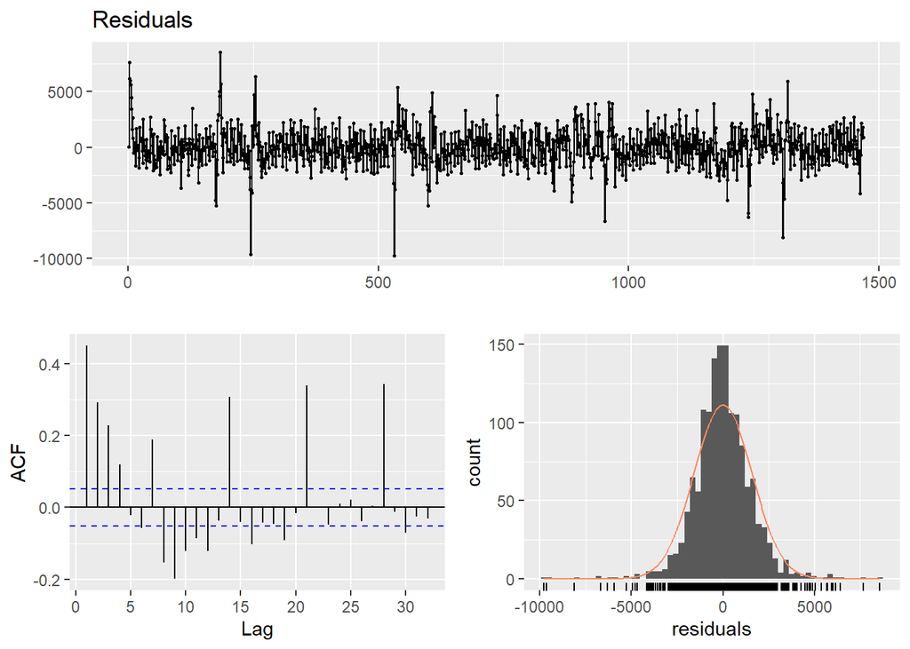

```
##
##  Breusch-Godfrey test for serial correlation of order up to 10
##
## data:  Residuals
## LM test = 714.28, df = 10, p-value < 2.2e-16
```

Let’s look at the autocorrelation values of residuals to look at the stationary state and the time dependent state of our model.

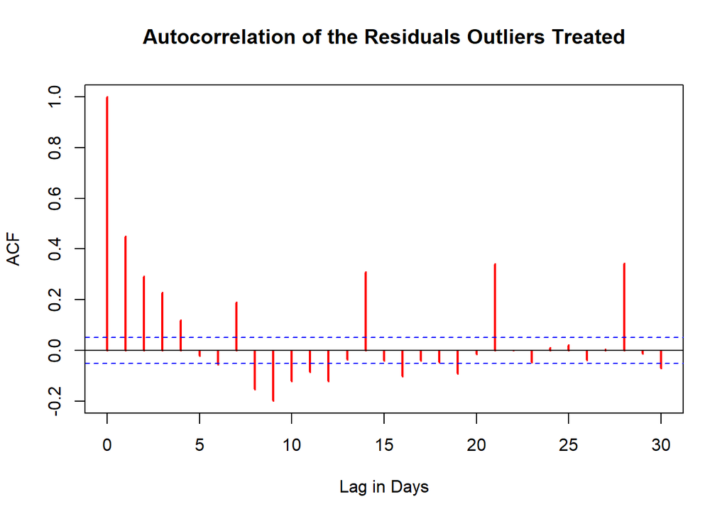

Unit Root KPSS test can be executed on the series to check if the assumption of stationarity is violated, in other words can be rejected,

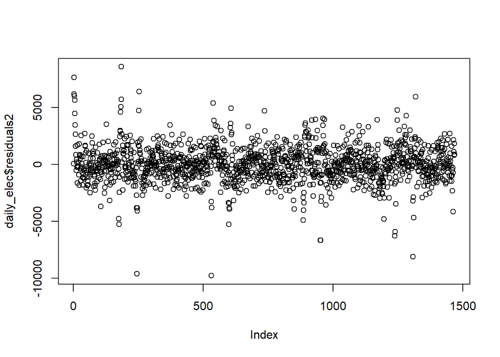

```
##
## #######################
## # KPSS Unit Root Test #
## #######################
##
## Test is of type: mu with 7 lags.
##
## Value of test-statistic is: 0.0486
##
## Critical value for a significance level of:
##                 10pct  5pct 2.5pct  1pct
## critical values 0.347 0.463  0.574 0.739
```

## Residuals

Let’s look at residuals so we may still advance the stationary state.

```
##
## #######################
## # KPSS Unit Root Test #
## #######################
##
## Test is of type: mu with 7 lags.
##
## Value of test-statistic is: 0.0257
##
## Critical value for a significance level of:
##                 10pct  5pct 2.5pct  1pct
## critical values 0.347 0.463  0.574 0.739
```

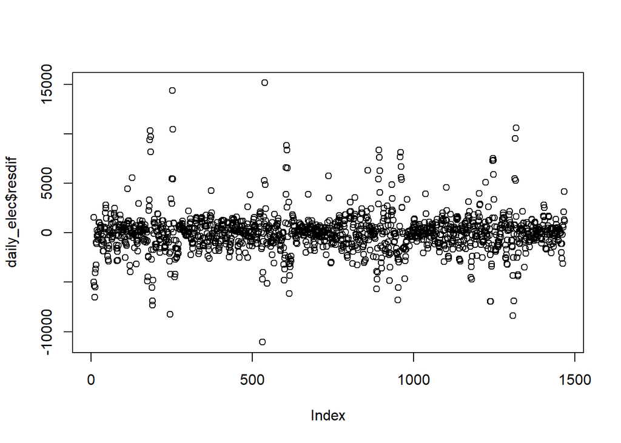

The current image is better than the images we looked at before. We can proceed to ARIMA and Forecast sections.

## Forecast

Before guessing, we should look at ARIMA models in order to decide what kind of prediction I will create for ARIMA over the last picture we created.

```
##
##  Fitting models using approximations to speed things up...
##
##  ARIMA(2,0,2) with non-zero mean : 25209.14
##  ARIMA(0,0,0) with non-zero mean : 26359.82
##  ARIMA(1,0,0) with non-zero mean : 25448.4
##  ARIMA(0,0,1) with non-zero mean : 25790.34
##  ARIMA(0,0,0) with zero mean     : 26357.99
##  ARIMA(1,0,2) with non-zero mean : 25420.44
##  ARIMA(2,0,1) with non-zero mean : 25430.4
##  ARIMA(3,0,2) with non-zero mean : 25260.74
##  ARIMA(2,0,3) with non-zero mean : 25098.38
##  ARIMA(1,0,3) with non-zero mean : 25252.89
##  ARIMA(3,0,3) with non-zero mean : 25253.76
##  ARIMA(2,0,4) with non-zero mean : Inf
##  ARIMA(1,0,4) with non-zero mean : 25222.69
##  ARIMA(3,0,4) with non-zero mean : 25218.08
##  ARIMA(2,0,3) with zero mean     : 25096.42
##  ARIMA(1,0,3) with zero mean     : 25251.73
##  ARIMA(2,0,2) with zero mean     : 25207.14
##  ARIMA(3,0,3) with zero mean     : 25252.06
##  ARIMA(2,0,4) with zero mean     : Inf
##  ARIMA(1,0,2) with zero mean     : 25418.47
##  ARIMA(1,0,4) with zero mean     : 25221.6
##  ARIMA(3,0,2) with zero mean     : 25259.49
##  ARIMA(3,0,4) with zero mean     : 25216.29
##
##  Now re-fitting the best model(s) without approximations...
##
##  ARIMA(2,0,3) with zero mean     : Inf
##  ARIMA(2,0,3) with non-zero mean : Inf
##  ARIMA(2,0,2) with zero mean     : 25129.62
##
##  Best model: ARIMA(2,0,2) with zero mean
```

ARIMA (2,0,2) model gives appropriate values and was chosen for use.

```
##      Point Forecast      Lo 80     Hi 80      Lo 95    Hi 95
## 1470      2249.8476   581.7574 3917.9378  -301.2762 4800.971
## 1471      1042.7512  -661.4013 2746.9036 -1563.5251 3649.027
## 1472      -179.2844 -2081.4956 1722.9268 -3088.4654 2729.897
## 1473     -1085.3381 -3237.2483 1066.5722 -4376.4007 2205.725
## 1474     -1501.7577 -3819.9218  816.4065 -5047.0838 2043.568
## 1475     -1424.2400 -3799.6731  951.1931 -5057.1515 2208.671
## 1476      -981.8570 -3359.8901 1396.1760 -4618.7447 2655.031
## 1477      -373.2095 -2762.9870 2016.5680 -4028.0588 3281.640
## 1478       202.0641 -2228.7446 2632.8728 -3515.5369 3919.665
## 1479       597.0412 -1882.2645 3076.3469 -3194.7297 4388.812
## 1480       745.3498 -1764.5836 3255.2832 -3093.2620 4583.962
## 1481       661.3046 -1857.4242 3180.0334 -3190.7586 4513.368
## 1482       418.3795 -2100.3824 2937.1414 -3433.7344 4270.493
## 1483       116.5384 -2406.3745 2639.4513 -3741.9240 3975.001
## 1484      -150.3743 -2683.6508 2382.9023 -4024.6864 3723.938
```

Since it was 15 days for us to estimate, 15 values were generated for residual difference values over the model in ARİMA.

We make predictions according to our Model 2 and ARİMA results.

```
##           Date forecasted_consumption
##  1: 2021-01-09               38625.92
##  2: 2021-01-10               35032.10
##  3: 2021-01-11               30668.62
##  4: 2021-01-12               35787.84
##  5: 2021-01-13               36236.45
##  6: 2021-01-14               35910.66
##  7: 2021-01-15               35971.01
##  8: 2021-01-16               34965.77
##  9: 2021-01-17               31137.41
## 10: 2021-01-18               29868.70
## 11: 2021-01-19               35728.90
## 12: 2021-01-20               35277.05
## 13: 2021-01-21               36283.49
## 14: 2021-01-22               33259.85
## 15: 2021-01-23               32066.53
```

## Conclusion

Modelimizin genel ölçmemiz gereklidir. Bunun için ilk olarak EPİAŞ tan tahmin etmemiz gereken 15 günün gerçek gönderim alarak tahmin ettiğimiz veri tablosu ile aynı formata getirmeliyiz.

```
##           Date mean_consumption
##  1: 2021-01-09         34781.56
##  2: 2021-01-10         31841.90
##  3: 2021-01-11         36431.46
##  4: 2021-01-12         36897.99
##  5: 2021-01-13         37409.87
##  6: 2021-01-14         38056.05
##  7: 2021-01-15         38170.38
##  8: 2021-01-16         35667.35
##  9: 2021-01-17         32557.96
## 10: 2021-01-18         38447.89
## 11: 2021-01-19         39723.73
## 12: 2021-01-20         39960.92
## 13: 2021-01-21         39791.07
## 14: 2021-01-22         38902.97
## 15: 2021-01-23         35635.70
```

```r
test <- function(actual, forecasted){
  n=length(actual)
  error = actual-forecasted
  mean=mean(actual)
  sd=sd(actual)
  bias = sum(error)/sum(actual)
  mape = sum(abs(error/actual))/n
  mad = sum(abs(error))/n
  wmape = mad/mean
  l = data.frame(n,mean,sd,bias,mape,mad,wmape)
  return(l)
}
test(dailytest$mean_consumption, forecast$forecasted_consumption)
```

```
##    n     mean       sd       bias       mape      mad      wmape
## 1 15 36951.79 2500.597 0.06757724 0.09212853 3435.041 0.09296009
```

When we look at this, we can say that the values are sufficient. It is a bit difficult to decide how much is sufficient for a model or table we have created for comparison. However, it is clear that this model can of course be much better. Different variables can be used to explain and stabilize seasonality and delay can be controlled for different intervals. We also tried to fix the special dates, but the combined holidays are also highly likely to create outliers. However, we could not correct these days as there is no concrete data regarding the combined holidays. Much better predictions will emerge with extra studies on these days or on other outlier-producing days.